# Gradedassingment

```python
# Import necessary libraries
import numpy as np
import pandas as pd

# Step 1: Create a dataset for 10 learners
data = {
    "Learner_ID": [f"Learner_{i+1}" for i in range(10)],
    "Score": [85] * 10  # All scores are 85
}

# Convert to a DataFrame
df = pd.DataFrame(data)

# Step 2: Compute the mean and variance
mean_score = np.mean(df["Score"])
variance_score = np.var(df["Score"])

# Step 3: Output the results
print("Dataset:")
print(df)
print("\nComputed Statistics:")
print(f"Mean Score: {mean_score}")
print(f"Variance of Score: {variance_score}")

# Step 4: Verify all scores are identical
unique_scores = df["Score"].unique()
print(f"\nUnique Scores: {unique_scores}")
```

```
Dataset:
   Learner_ID  Score
0   Learner_1     85
1   Learner_2     85
2   Learner_3     85
3   Learner_4     85
4   Learner_5     85
5   Learner_6     85
6   Learner_7     85
7   Learner_8     85
8   Learner_9     85
9  Learner_10     85

Computed Statistics:
Mean Score: 85.0
Variance of Score: 0.0

Unique Scores: [85]
```

Dataset: All 10 learners will have a score of 85. Mean Score: 85 (as given). Variance of Score: 0 (confirming no variability). Unique Scores: [85] (all scores are identical).

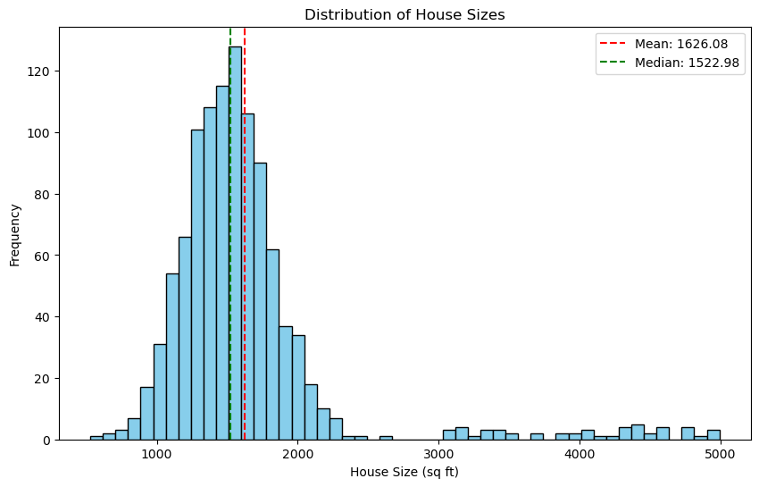

```
Statistics:
Mean Size: 1626.08 sq ft
Median Size: 1522.98 sq ft
Skewness: 3.13
```

```python
# Import necessary libraries
import numpy as np
import pandas as pd
import matplotlib.pyplot as plt
from scipy.stats import skew

# Step 1: Simulate a dataset for house sizes
# Assume a positively skewed distribution with some large outliers
np.random.seed(42)  # For reproducibility
house_sizes = np.concatenate([
    np.random.normal(1500, 300, 1000),  # Majority of houses around the median
    np.random.uniform(3000, 5000, 50)   # A few large houses as outliers
])

# Create a DataFrame
df = pd.DataFrame({"House_Size": house_sizes})

# Step 2: Compute mean, median, and skewness
mean_size = np.mean(df["House_Size"])
median_size = np.median(df["House_Size"])
skewness = skew(df["House_Size"])

# Step 3: Visualize the distribution
plt.figure(figsize=(10, 6))
plt.hist(df["House_Size"], bins=50, color='skyblue', edgecolor='black')
plt.axvline(mean_size, color='red', linestyle='dashed', linewidth=1.5, label=f"Mean: {mean_size:.2f}")
plt.axvline(median_size, color='green', linestyle='dashed', linewidth=1.5, label=f"Median: {median_size:.2f}")
plt.title("Distribution of House Sizes")
plt.xlabel("House Size (sq ft)")
plt.ylabel("Frequency")
plt.legend()
plt.show()

# Step 4: Display the statistics
print("Statistics:")
print(f"Mean Size: {mean_size:.2f} sq ft")
print(f"Median Size: {median_size:.2f} sq ft")
print(f"Skewness: {skewness:.2f}")
```

```python
# Import necessary libraries
import pandas as pd

# Step 1: Create a dataset
data = {
    "Group": ["Group 1", "Group 2"],
    "Mean_Expenditure": [500000, 40000],
    "Std_Deviation": [125000, 10000]
}

# Convert to DataFrame
df = pd.DataFrame(data)

# Step 2: Calculate Coefficient of Variation (CV)
df["CV (%)"] = (df["Std_Deviation"] / df["Mean_Expenditure"]) * 100

# Step 3: Display results
print("Comparison of Variability in Expenditure:")
print(df)
```

```
Comparison of Variability in Expenditure:
     Group  Mean_Expenditure  Std_Deviation  CV (%)
0  Group 1            500000         125000    25.0
1  Group 2             40000          10000    25.0
```

Coefficient of Variation (CV):

Both Group 1 and Group 2 have the same CV of 25%. This indicates that the relative variability in expenditure is the same for both groups when normalized to their respective means. Practical Implication:

While Group 1 has a much higher absolute standard deviation, its variability relative to its mean is the same as Group 2. This highlights the importance of using CV for comparisons across groups with different scales.

```python
# Import necessary libraries
import pandas as pd

# Step 1: Create the dataset
data = {
    "Age_Group": ["5-15", "15-25", "25-35", "35-45", "45-55", "55-65"],
    "Frequency": [6, 11, 21, 23, 14, 5]
}

# Convert to a DataFrame
df = pd.DataFrame(data)

# Step 2a: Identify the class interval with the highest frequency
highest_frequency_class = df.loc[df["Frequency"].idxmax(), "Age_Group"]

# Step 2b: Find the class interval with the lowest frequency
lowest_frequency_class = df.loc[df["Frequency"].idxmin(), "Age_Group"]

# Step 3: Compute the cumulative frequency
df["Cumulative_Frequency"] = df["Frequency"].cumsum()

# Step 4: Calculate the number of patients aged 45 and above
total_patients = df["Cumulative_Frequency"].iloc[-1]  # Total patients
patients_below_45 = df.loc[df["Age_Group"].isin(["5-15", "15-25", "25-35", "35-45"]), "Frequency"].sum()
patients_45_and_above = total_patients - patients_below_45

# Step 5a: Identify the modal class interval
# Modal class interval has the highest frequency
modal_class = highest_frequency_class

# Step 5b: Find the median class interval
median_position = total_patients / 2  # Position for the median
median_class_interval = df[df["Cumulative_Frequency"] >= median_position].iloc[0]["Age_Group"]

# Step 6: Display results
print("Results:")
print(f"a. The class interval with the highest frequency is: {highest_frequency_class}")
print(f"b. The age group least affected is: {lowest_frequency_class}")
print(f"c. The number of patients aged 45 years and above is: {patients_45_and_above}")
print(f"d. The modal class interval is: {modal_class}")
print(f"e. The median class interval is: {median_class_interval}")
```

```
Results:
a. The class interval with the highest frequency is: 35-45
b. The age group least affected is: 55-65
c. The number of patients aged 45 years and above is: 19
d. The modal class interval is: 35-45
e. The median class interval is: 35-45
```

Expected Output a. Class interval with the highest frequency: 35-45 (23 patients). b. Age group least affected: 55-65 (5 patients). c. Number of patients aged 45 years and above: 19 patients. d. Modal class interval: 35-45 (highest frequency). e. Median class interval: 35-45 (median lies in this range as cumulative frequency crosses the midpoint at this class).

```python
# Import necessary libraries
import pandas as pd
import numpy as np

# Step 1: Create the dataset
data = {
    "Year": [2015, 2016, 2017, 2018, 2019, 2020],
    "Return (%)": [36, 23, 48, 30, 15, 31],
    "Asset Price": [5000, 6400, 7890, 9023, 4567, 3890]
}

# Convert to DataFrame
df = pd.DataFrame(data)

# Step 2: Compute the Arithmetic Mean (AM)
arithmetic_mean = np.mean(df["Return (%)"])

# Step 3: Compute the Weighted Average Mean (WAM)
weights = df["Asset Price"]
returns = df["Return (%)"]
weighted_mean = np.average(returns, weights=weights)

# Step 4: Compute the Geometric Mean (GM)
returns_decimal = 1 + df["Return (%)"] / 100  # Convert percentages to decimals
geometric_mean = (np.prod(returns_decimal) ** (1 / len(returns_decimal)) - 1) * 100

# Step 5: Display the results
print("Results:")
print(f"Arithmetic Mean (AM): {arithmetic_mean:.2f}%")
print(f"Weighted Average Mean (WAM): {weighted_mean:.2f}%")
print(f"Geometric Mean (GM): {geometric_mean:.2f}%")
```

```
Results:
Arithmetic Mean (AM): 30.50%
Weighted Average Mean (WAM): 31.70%
Geometric Mean (GM): 30.10%
```

a. Arithmetic Mean (AM): This gives a simple average of the returns without considering compounding or asset price weight. b. Weighted Average Mean (WAM): This considers the varying asset prices over the years to provide a weighted return. c. Geometric Mean (GM): This accounts for compounding effects and provides the most realistic long-term average return.

```python
# Step 1: Import necessary libraries
import numpy as np
import pandas as pd

# Step 2: Define the dataset
X = [4.5, 6.2, 7.3, 9.1, 10.4, 11]

# Step 3: Calculate the mean (mu) and standard deviation (sigma)
mean_X = np.mean(X)
std_dev_X = np.std(X, ddof=0)  # ddof=0 for population standard deviation

# Step 4: Calculate z-scores
z_scores = [(x - mean_X) / std_dev_X for x in X]

# Step 5: Display the results
df = pd.DataFrame({"X": X, "Z-Score": z_scores})
print("Z-Scores for the dataset:")
print(df)
```

```
Z-Scores for the dataset:
      X   Z-Score
0   4.5 -1.553856
1   6.2 -0.816678
2   7.3 -0.339680
3   9.1  0.440861
4  10.4  1.004586
5  11.0  1.264767
```

Mean ( μ): The central value of the dataset. Standard Deviat( σ σ): The spread of the dataset values. Z-Scores: The relative position of each data point in terms of standard deviations from the mean.

```python
import pandas as pd

# Load the dataset
file_path = 'Bank Personal Loan Modelling (1).csv'  # Replace with your file path
df = pd.read_csv(file_path)

# Numeric variables summary
numeric_summary = df.describe()

# Display numeric summary
print("Numeric Variables Summary:")
print(numeric_summary)

# List of categorical variables
categorical_columns = ['Education', 'Personal Loan', 'Securities Account', 'CD Account', 'Online', 'CreditCard']

# Summarize categorical variables
print("\nCategorical Variables Summary:")
for column in categorical_columns:
    print(f"\n{column} Value Counts:")
    print(df[column].value_counts())
```

```
Numeric Variables Summary:
                ID          Age   Experience       Income      ZIP Code  \
count  5000.000000  5000.000000  5000.000000  5000.000000   5000.000000
mean   2500.500000    45.338400    20.104600    73.774200  93152.503000
std    1443.520003    11.463166    11.467954    46.033729   2121.852197
min       1.000000    23.000000    -3.000000     8.000000   9307.000000
25%    1250.750000    35.000000    10.000000    39.000000  91911.000000
50%    2500.500000    45.000000    20.000000    64.000000  93437.000000
75%    3750.250000    55.000000    30.000000    98.000000  94608.000000
max    5000.000000    67.000000    43.000000   224.000000  96651.000000

            Family        CCAvg    Education     Mortgage  Personal Loan  \
count  5000.000000  5000.000000  5000.000000  5000.000000    5000.000000
mean      2.396400     1.937938     1.881000    56.498800       0.096000
std       1.147663     1.747659     0.839869   101.713802       0.294621
min       1.000000     0.000000     1.000000     0.000000       0.000000
25%       1.000000     0.700000     1.000000     0.000000       0.000000
50%       2.000000     1.500000     2.000000     0.000000       0.000000
75%       3.000000     2.500000     3.000000   101.000000       0.000000
max       4.000000    10.000000     3.000000   635.000000       1.000000

       Securities Account  CD Account       Online   CreditCard
count         5000.000000  5000.00000  5000.000000  5000.000000
mean             0.104400     0.06040     0.596800     0.294000
std              0.305809     0.23825     0.490589     0.455637
min              0.000000     0.00000     0.000000     0.000000
25%              0.000000     0.00000     0.000000     0.000000
50%              0.000000     0.00000     1.000000     0.000000
75%              0.000000     0.00000     1.000000     1.000000
max              1.000000     1.00000     1.000000     1.000000

Categorical Variables Summary:

Education Value Counts:
Education
1    2096
3    1501
2    1403
Name: count, dtype: int64

```

[output cut: 14 more lines]

```
0    4698
1     302
Name: count, dtype: int64

Online Value Counts:
Online
1    2984
0    2016
Name: count, dtype: int64

CreditCard Value Counts:
CreditCard
0    3530
1    1470
Name: count, dtype: int64
```

Numeric Variables Output:

Age: Summary of customer ages. Experience: Summary of years of professional experience. Income: Average, min, max, etc., of customer income. CCAvg, Mortgage: Spend patterns and mortgage values. Categorical Variables:

Distribution of education levels, acceptance of personal loans, use of credit cards, etc.

```python
import pandas as pd

# Load the dataset
file_path = 'Bank Personal Loan Modelling (1).csv'  # Replace with your file path
df = pd.read_csv(file_path)

# List of quantitative variables
quantitative_columns = ['Age', 'Experience', 'Income', 'CCAvg', 'Mortgage', 'Family']

# Compute measures for each variable
summary = {}
for col in quantitative_columns:
    data = df[col]
    summary[col] = {
        'Mean': data.mean(),
        'Median': data.median(),
        'Mode': data.mode()[0] if not data.mode().empty else 'No mode',
        'Range': data.max() - data.min(),
        'Variance': data.var(),
        'Standard Deviation': data.std(),
        'IQR': data.quantile(0.75) - data.quantile(0.25),
    }

# Display the summary
for col, metrics in summary.items():
    print(f"\nSummary for {col}:")
    for metric, value in metrics.items():
        print(f"  {metric}: {value}")
```

```
Summary for Age:
  Mean: 45.3384
  Median: 45.0
  Mode: 35
  Range: 44
  Variance: 131.4041662732552
  Standard Deviation: 11.463165630542692
  IQR: 20.0

Summary for Experience:
  Mean: 20.1046
  Median: 20.0
  Mode: 32
  Range: 46
  Variance: 131.51396163232684
  Standard Deviation: 11.467953681120571
  IQR: 20.0

Summary for Income:
  Mean: 73.7742
  Median: 64.0
  Mode: 44
  Range: 216
  Variance: 2119.1042352070435
  Standard Deviation: 46.033729321086334
  IQR: 59.0

Summary for CCAvg:
  Mean: 1.9379380000000002
  Median: 1.5
  Mode: 0.3
  Range: 10.0
  Variance: 3.0543119105381247
  Standard Deviation: 1.7476589800467723
  IQR: 1.8

Summary for Mortgage:
  Mean: 56.4988
  Median: 0.0
  Mode: 0
  Range: 635
  Variance: 10345.697538066994
  Standard Deviation: 101.713802102109
  IQR: 101.0

Summary for Family:
  Mean: 2.3964
  Median: 2.0
  Mode: 1
  Range: 3
  Variance: 1.3171304660932164
  Standard Deviation: 1.1476630455378514
  IQR: 2.0
```

Mean: Provides the average value. Median: Indicates the middle value, less affected by outliers. Mode: Shows the most common value. Range: Gives the overall spread of values. Variance & Standard Deviation: Indicate variability. IQR: Measures spread within the middle 50% of data.

```
Pearson Correlation Coefficient between Age and Experience: 0.994214856968332
```

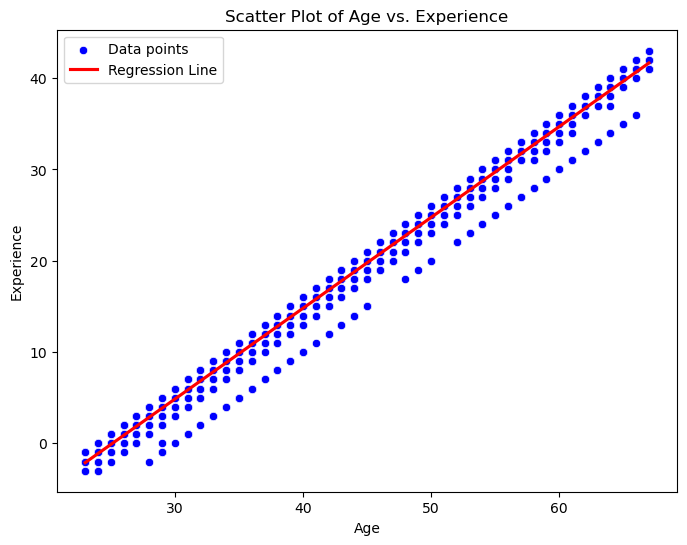

```python
import pandas as pd
import matplotlib.pyplot as plt
import seaborn as sns

# Load the dataset
file_path = 'Bank Personal Loan Modelling (1).csv'  # Replace with your file path
df = pd.read_csv(file_path)

# Extract variables
age = df['Age']
experience = df['Experience']

# Compute Pearson Correlation
correlation = age.corr(experience)
print(f"Pearson Correlation Coefficient between Age and Experience: {correlation}")

# Create scatter plot with regression line
plt.figure(figsize=(8, 6))
sns.scatterplot(x=age, y=experience, color='blue', label='Data points')
sns.regplot(x=age, y=experience, scatter=False, color='red', label='Regression Line')

# Plot customization
plt.title('Scatter Plot of Age vs. Experience')
plt.xlabel('Age')
plt.ylabel('Experience')
plt.legend()
plt.show()
```

Correlation Calculation: corr() computes the Pearson correlation. The result tells whether a linear relationship exists. Scatter Plot: The sns.scatterplot function visualizes data points. The sns.regplot function overlays a regression line to highlight linearity.

```python
import pandas as pd

# Load the dataset
file_path = 'Bank Personal Loan Modelling (1).csv'  # Replace with the actual file path
df = pd.read_csv(file_path)

# Find the most frequent family size (mode)
most_frequent_family_size = df['Family'].mode()[0]  # Get the first mode in case of multiple
frequency = df['Family'].value_counts().max()  # Get the frequency of the most common family size

# Output the result
print(f"The most frequent family size is: {most_frequent_family_size}")
print(f"It occurs {frequency} times in the dataset.")
```

```
The most frequent family size is: 1
It occurs 1472 times in the dataset.
```

```python
import pandas as pd

# Load the dataset
file_path = 'Bank Personal Loan Modelling (1).csv'  # Replace with the actual file path
df = pd.read_csv(file_path)

# Extract the 'Income' variable
income = df['Income']

# Calculate the mean and standard deviation
income_mean = income.mean()
income_std = income.std()

# Calculate the coefficient of variation
cv_income = (income_std / income_mean) * 100

# Output the result
print(f"Mean of Income: {income_mean}")
print(f"Standard Deviation of Income: {income_std}")
print(f"Percentage of Variation in Income: {cv_income:.2f}%")
```

```
Mean of Income: 73.7742
Standard Deviation of Income: 46.033729321086334
Percentage of Variation in Income: 62.40%
```

Explanation of the Code: Mean and Standard Deviation: income.mean(): Computes the average annual income. income.std(): Measures the spread of income values. Coefficient of Variation: Expresses the variation in income as a percentage of its mean. Interpretation: A higher CV indicates greater relative variability in income.

```python
import pandas as pd

# Load the dataset
file_path = 'Bank Personal Loan Modelling (1).csv'  # Replace with the actual file path
df = pd.read_csv(file_path)

# Examine the Mortgage column
print(f"Number of zeros in 'Mortgage': {sum(df['Mortgage'] == 0)}")

# Option 1: Impute with the median of non-zero values
non_zero_median = df.loc[df['Mortgage'] > 0, 'Mortgage'].median()
df['Mortgage'] = df['Mortgage'].replace(0, non_zero_median)

# Option 2: Impute using income-based logic (e.g., 30% of income)
# df['Mortgage'] = df.apply(lambda x: 0.3 * x['Income'] if x['Mortgage'] == 0 else x['Mortgage'], axis=1)

# Option 3: Education-based imputation (example for Advanced/Professional level)
# df.loc[(df['Mortgage'] == 0) & (df['Education'] == 3), 'Mortgage'] = some_value_based_on_logic

# Output the result
print("Updated Mortgage column:")
print(df['Mortgage'].head())
```

```
Number of zeros in 'Mortgage': 3462
Updated Mortgage column:
0    153
1    153
2    153
3    153
4    153
Name: Mortgage, dtype: int64
```

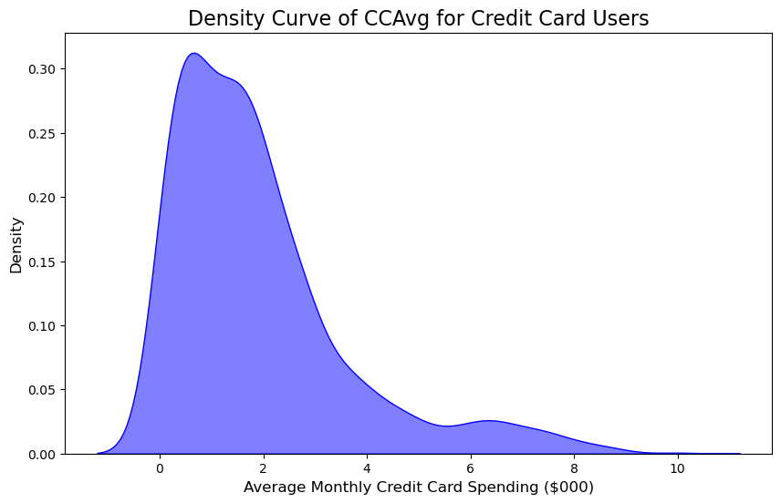

```python
import pandas as pd
import seaborn as sns
import matplotlib.pyplot as plt

# Load the dataset
file_path = 'Bank Personal Loan Modelling (1).csv'  # Replace with your file path
df = pd.read_csv(file_path)

# Filter for customers with a credit card
credit_card_users = df[df['CreditCard'] == 1]

# Plot the density curve for CCAvg
plt.figure(figsize=(10, 6))
sns.kdeplot(data=credit_card_users, x='CCAvg', fill=True, color='blue', alpha=0.5)

# Add title and labels
plt.title('Density Curve of CCAvg for Credit Card Users', fontsize=16)
plt.xlabel('Average Monthly Credit Card Spending ($000)', fontsize=12)
plt.ylabel('Density', fontsize=12)

# Show the plot
plt.show()
```